# Data Mining Assignment 3

Jonathan Kuek

9 November 2015

```r
library(lars)
library(pls)
```

Q1)  
Based on my mid term findings, the OLS model for apartment prices would be as follow:

```r
training <- readRDS(gzcon(url('https://courseworks.columbia.edu/x/pJdP39')))
testing <- readRDS(gzcon(url('https://courseworks.columbia.edu/x/QnKLgY')))

ols <- lm(totalprice ~ area + zone + category + age + floor + rooms + out + conservation + toilets + garage + elevator + streetcategory + heating + storage, data = training)
round(coef(summary(ols))[,1:3], 2)
```

```
##                   Estimate Std. Error t value
## (Intercept)      120036.03   57115.42    2.10
## area               1757.93     278.00    6.32
## zoneZ21           55881.01   24822.14    2.25
## zoneZ31           50637.34   24683.70    2.05
## zoneZ32           -2576.59   24381.60   -0.11
## zoneZ34          -38176.47   29158.13   -1.31
## zoneZ35            8056.55   29000.63    0.28
## zoneZ36           -7325.99   24007.48   -0.31
## zoneZ37           31387.52   23678.42    1.33
## zoneZ38          -15322.49   28150.34   -0.54
## zoneZ41           10768.88   25980.87    0.41
## zoneZ42           31364.06   28686.17    1.09
## zoneZ43           -9757.10   32942.03   -0.30
## zoneZ44          -16243.08   26290.63   -0.62
## zoneZ45          -42276.19   25704.72   -1.64
## zoneZ46          -34374.87   27696.27   -1.24
## zoneZ47          -65493.37   28372.08   -2.31
## zoneZ48           -3194.81   28402.74   -0.11
## zoneZ49          -12600.50   30136.43   -0.42
## zoneZ52          -43550.19   25526.70   -1.71
## zoneZ53          -18369.38   26317.30   -0.70
## zoneZ56          -26214.61   30451.73   -0.86
## zoneZ61          -15190.58   22940.65   -0.66
## zoneZ62          -30660.81   25261.38   -1.21
## category2B        29408.59   33437.32    0.88
## category3A        21089.26   34866.94    0.60
## category3B        22923.14   35705.00    0.64
## category4A        13362.29   36118.75    0.37
## category4B        -7676.42   38591.72   -0.20
## category5A       -61890.65   54983.26   -1.13
## age                -573.45     285.90   -2.01
## floor              -679.25    1476.04   -0.46
## rooms               606.97    5900.95    0.10
## outE25            21756.78   40604.01    0.54
## outE50            -8661.88    7392.73   -1.17
## outE75             1441.22   18019.20    0.08
## conservation2A   -10510.88   12846.22   -0.82
## conservation2B     3984.82    9963.88    0.40
## conservation3A    12423.72   21883.01    0.57
## toilets           15736.76   10034.99    1.57
## garage            23163.08    7650.90    3.03
## elevator          19245.75    9073.23    2.12
## streetcategoryS3  15753.23    9756.94    1.61
## streetcategoryS4   3267.34   10889.33    0.30
## streetcategoryS5  -4360.46   14012.48   -0.31
## heating3A        -48678.10   21046.32   -2.31
## heating3B         -7788.99   29032.30   -0.27
## heating4A        -31750.91   21751.69   -1.46
## storage            3356.48    7953.00    0.42
```

```r
X <- model.matrix(ols)
y <- training$totalprice

ll <- function(beta) {
  estimates <- (X %*% beta)
  return( sum((estimates - y) ^ 2) )
}

opt <- optim(rep(0, ncol(X)), fn = ll, method = "BFGS")
cbind(coef(ols), opt$par)
```

```
##                         [,1]        [,2]
## (Intercept)      120036.0269 120018.0335
## area               1757.9349   1757.9172
## zoneZ21           55881.0059  55872.9338
## zoneZ31           50637.3439  50629.0868
## zoneZ32           -2576.5912  -2583.7753
## zoneZ34          -38176.4699 -38190.8604
## zoneZ35            8056.5478   8050.6356
## zoneZ36           -7325.9942  -7333.3030
## zoneZ37           31387.5174  31378.1678
## zoneZ38          -15322.4854 -15328.6671
## zoneZ41           10768.8755  10760.1134
## zoneZ42           31364.0563  31355.6825
## zoneZ43           -9757.0992  -9763.6915
## zoneZ44          -16243.0836 -16250.4109
## zoneZ45          -42276.1911 -42284.6896
## zoneZ46          -34374.8662 -34382.7836
## zoneZ47          -65493.3705 -65500.0624
## zoneZ48           -3194.8111  -3202.8403
## zoneZ49          -12600.4974 -12610.9495
## zoneZ52          -43550.1890 -43560.0873
## zoneZ53          -18369.3780 -18377.1454
## zoneZ56          -26214.6080 -26217.6226
## zoneZ61          -15190.5846 -15198.2391
## zoneZ62          -30660.8061 -30668.4588
## category2B        29408.5873  29428.9175
## category3A        21089.2563  21111.5055
## category3B        22923.1437  22945.2575
## category4A        13362.2916  13384.6105
## category4B        -7676.4247  -7653.8260
## category5A       -61890.6454 -61874.0014
## age                -573.4487   -573.4951
## floor              -679.2499   -679.2110
## rooms               606.9747    608.0650
## outE25            21756.7783  21764.3901
## outE50            -8661.8836  -8661.1936
## outE75             1441.2167   1439.2213
## conservation2A   -10510.8845 -10511.0077
## conservation2B     3984.8230   3985.6202
## conservation3A    12423.7204  12425.3553
## toilets           15736.7595  15736.2172
## garage            23163.0849  23163.9223
## elevator          19245.7545  19246.1043
## streetcategoryS3  15753.2289  15751.7917
## streetcategoryS4   3267.3444   3264.8703
## streetcategoryS5  -4360.4586  -4362.9229
## heating3A        -48678.1001 -48676.5824
## heating3B         -7788.9869  -7780.8210
## heating4A        -31750.9120 -31748.7074
## storage            3356.4789   3357.0154
```

Q2)

```r
PCR <- pcr(totalprice ~ area + zone + category + age + floor + rooms + out + conservation + toilets + garage + elevator + streetcategory + heating + storage, data = training, validation = "LOO")
summary(PCR)
```

```
## Data:    X dimension: 109 48
##  Y dimension: 109 1
## Fit method: svdpc
## Number of components considered: 48
##
## VALIDATION: RMSEP
## Cross-validated using 109 leave-one-out segments.
##        (Intercept)  1 comps  2 comps  3 comps  4 comps  5 comps  6 comps
## CV           71264    37653    38313    38211    36718    37019    36158
## adjCV        71264    37630    38305    38201    36698    37006    36107
##        7 comps  8 comps  9 comps  10 comps  11 comps  12 comps  13 comps
## CV       36249    36474    37161     37670     36440     36501     36837
## adjCV    36230    36453    37142     37654     36413     36473     36811
##        14 comps  15 comps  16 comps  17 comps  18 comps  19 comps
## CV        37153     37821     37577     37727     37417     37498
## adjCV     37141     37795     37545     37698     37372     37467
##        20 comps  21 comps  22 comps  23 comps  24 comps  25 comps
## CV        38486     36203     36259     37256     37371     37864
## adjCV     38476     36171     36204     37268     37367     38014
##        26 comps  27 comps  28 comps  29 comps  30 comps  31 comps
## CV        35190     34447     32585     32390     31874     32365
## adjCV     35115     34294     32514     32303     31831     32319
##        32 comps  33 comps  34 comps  35 comps  36 comps  37 comps
## CV        31947     32223     32532     32877     32982     30895
## adjCV     31885     32176     32502     32840     32985     30808
##        38 comps  39 comps  40 comps  41 comps  42 comps  43 comps
## CV        30213     30494     30970     31689     30516     30103
## adjCV     30137     30448     30947     31644     30427     30047
##        44 comps  45 comps  46 comps  47 comps   48 comps
## CV        31496     32002     32503     33041  8.897e+16
## adjCV     31432     31934     32431     32967  8.856e+16
##
## TRAINING: % variance explained
##             1 comps  2 comps  3 comps  4 comps  5 comps  6 comps  7 comps
## X             57.24    98.70    99.45    99.52    99.58    99.62    99.66
## totalprice    72.88    73.01    73.75    76.38    76.55    78.45    78.64
##             8 comps  9 comps  10 comps  11 comps  12 comps  13 comps
## X             99.69    99.73     99.75     99.77     99.79     99.81
## totalprice    78.76    78.76     78.76     80.40     80.45     80.48
##             14 comps  15 comps  16 comps  17 comps  18 comps  19 comps
## X              99.83     99.85     99.86     99.87     99.88     99.89
## totalprice     80.54     80.72     81.23     81.35     82.18     82.22
##             20 comps  21 comps  22 comps  23 comps  24 comps  25 comps
## X              99.90     99.91     99.92     99.92     99.93     99.94
## totalprice     82.34     84.34     85.36     85.38     86.12     86.60
##             26 comps  27 comps  28 comps  29 comps  30 comps  31 comps
## X              99.94     99.95     99.95     99.96     99.96     99.97
## totalprice     88.51     89.41     89.67     89.86     89.86     89.96
##             32 comps  33 comps  34 comps  35 comps  36 comps  37 comps
## X              99.97     99.98     99.98     99.98     99.98     99.99
## totalprice     90.21     90.22     90.28     90.62     90.83     91.77
##             38 comps  39 comps  40 comps  41 comps  42 comps  43 comps
## X              99.99     99.99     99.99    100.00    100.00    100.00
## totalprice     92.00     92.01     92.26     92.72     93.27     93.32
##             44 comps  45 comps  46 comps  47 comps  48 comps
## X             100.00    100.00    100.00    100.00    100.00
## totalprice     93.43     93.59     93.75     93.75     93.78
```

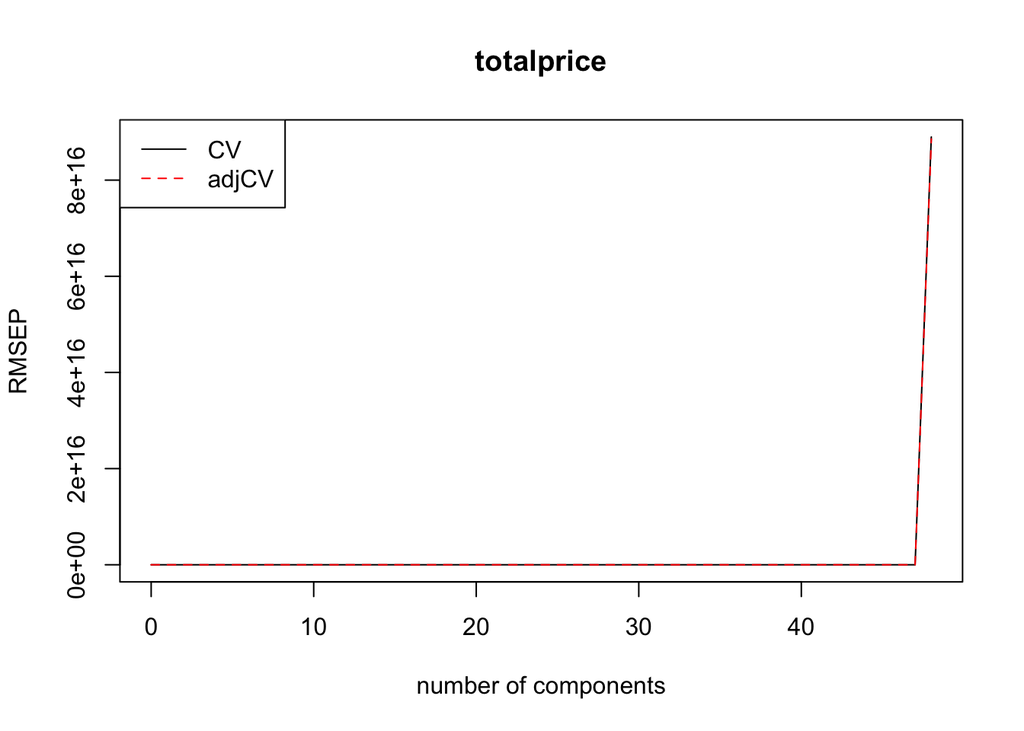

```r
plot(RMSEP(PCR), legendpos = "topleft")
```

```r
PCR_prediction <- predict(PCR, newdata = testing)
PCR_RMS <- RMSEP(PCR, newdata = testing)
PCR_RMS
```

```
## (Intercept)      1 comps      2 comps      3 comps      4 comps
##       67646        39806        39336        39646        40749
##     5 comps      6 comps      7 comps      8 comps      9 comps
##       40334        38011        37815        37859        37867
##    10 comps     11 comps     12 comps     13 comps     14 comps
##       37881        34528        34578        34593        34474
##    15 comps     16 comps     17 comps     18 comps     19 comps
##       34421        33411        33166        32523        32581
##    20 comps     21 comps     22 comps     23 comps     24 comps
##       33316        33895        33948        33746        33431
##    25 comps     26 comps     27 comps     28 comps     29 comps
##       34320        34594        32720        32167        32408
##    30 comps     31 comps     32 comps     33 comps     34 comps
##       32383        33005        33151        33321        33045
##    35 comps     36 comps     37 comps     38 comps     39 comps
##       32823        32216        31591        32697        32619
##    40 comps     41 comps     42 comps     43 comps     44 comps
##       31330        31017        29592        29095        28630
##    45 comps     46 comps     47 comps     48 comps
##       30489        29429        29591        29763
```

```r
PCR_SE <- 28630 ^ 2
PCR_SE
```

```
## [1] 819676900
```

Based on the lowest Root Mean Squared Error, we can obtain the lowest average squared error which is 44 comps, so k = 44.

```r
#OLS Error from mid terms
y_hat <- predict(ols, newdata = testing)
OLS_SE <- with(testing, mean((totalprice - y_hat)^2))
OLS_SE
```

```
## [1] 885812325
```

```r
PCR_SE - OLS_SE
```

```
## [1] -66135425
```

Yes, I obtained a lower average squared error as compared to the midterms.  
Q3)

```r
load("~/Desktop/Columbia Fall Courses/G4058 Data Mining/Homework/Homework 3/dataset.RData")
set.seed(222)
sub <- sample(nrow(dataset), floor(nrow(dataset) * 0.8))
training <- dataset[sub, ]
testing <- dataset[-sub, ]
```

loan_amnt and installment are both numerical so I will plotting them into the scatterplot.

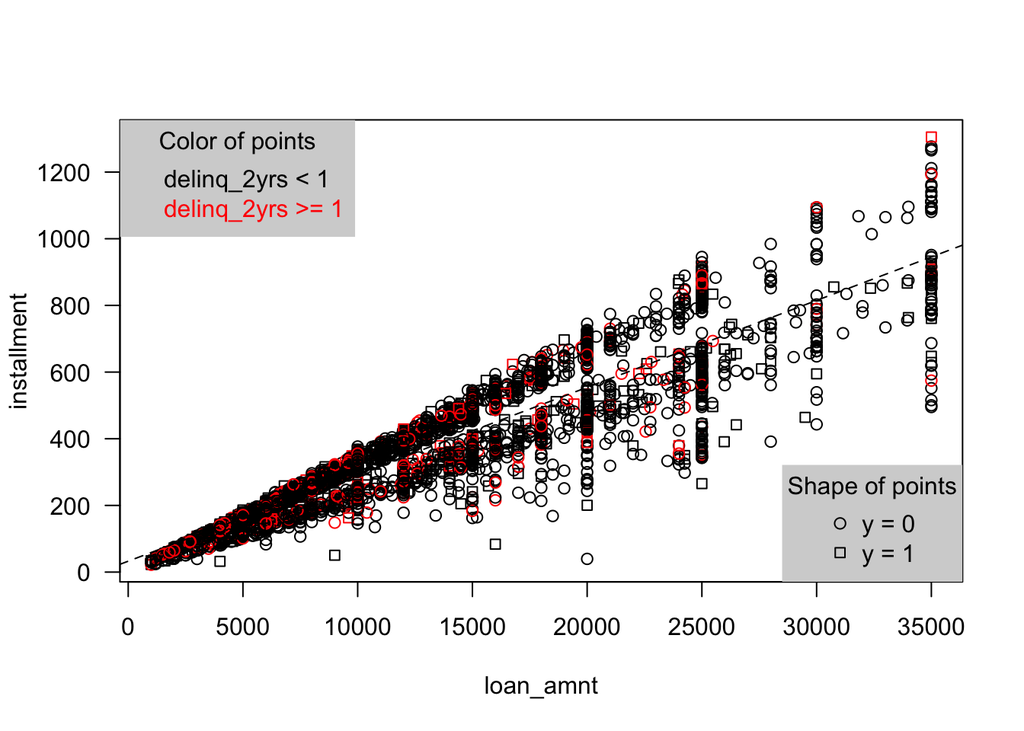

```r
par(pch = 20, las = 1)
with(training, plot(x = loan_amnt, y = installment, col = ifelse(delinq_2yrs < 1,1,2), pch = ifelse(y == 0,21,22)))

abline(lm(installment ~ loan_amnt, data = training), lty = "dashed")
legend("topleft", legend = c("delinq_2yrs < 1","delinq_2yrs >= 1"), text.col = 1:2, title = "Color of points",
bg = "lightgray", box.lwd = 0)
legend("bottomright", legend = c("y = 0","y = 1"), pch = 21:22, title = "Shape of points",
bg = "lightgray", box.lwd = 0)
```

Looing at the scatterplot, it seems to me that delinq_2yrs alone is not that good a predictor of whether someone defaults.

Initial Model

```r
glm_logit <- glm(y ~ loan_amnt + installment + loan_amnt*installment + as.factor(delinq_2yrs), data = training)
summary(glm_logit)
```

```
##
## Call:
## glm(formula = y ~ loan_amnt + installment + loan_amnt * installment +
##     as.factor(delinq_2yrs), data = training)
##
## Deviance Residuals:
##     Min       1Q   Median       3Q      Max
## -0.3573  -0.1395  -0.1260  -0.1192   0.8955
##
## Coefficients:
##                           Estimate Std. Error t value Pr(>|t|)
## (Intercept)              1.341e-01  1.454e-02   9.218  < 2e-16 ***
## loan_amnt                9.614e-06  1.959e-06   4.908 9.46e-07 ***
## installment             -3.793e-04  7.667e-05  -4.947 7.78e-07 ***
## as.factor(delinq_2yrs)1  9.962e-03  1.727e-02   0.577   0.5640
## as.factor(delinq_2yrs)2  9.407e-02  3.959e-02   2.376   0.0175 *
## as.factor(delinq_2yrs)3  7.068e-02  6.391e-02   1.106   0.2688
## as.factor(delinq_2yrs)4  1.454e-01  1.320e-01   1.102   0.2705
## as.factor(delinq_2yrs)5 -1.182e-01  2.467e-01  -0.479   0.6320
## loan_amnt:installment    4.302e-09  2.508e-09   1.715   0.0863 .
## ---
## Signif. codes:  0 '***' 0.001 '**' 0.01 '*' 0.05 '.' 0.1 ' ' 1
##
## (Dispersion parameter for gaussian family taken to be 0.1216515)
##
##     Null deviance: 651.10  on 5303  degrees of freedom
## Residual deviance: 644.14  on 5295  degrees of freedom
## AIC: 3889.7
##
## Number of Fisher Scoring iterations: 2
```

```r
y_hat_glm <- predict(glm_logit, newdata = testing, type = "response")
summary(y_hat_glm)
```

```
##    Min. 1st Qu.  Median    Mean 3rd Qu.    Max.
##  0.1030  0.1229  0.1286  0.1455  0.1525  0.3604
```

```r
z_glm <- as.integer(y_hat_glm > 0.5)
table(testing$y, z_glm)
```

```
##    z_glm
##        0
##   0 1121
##   1  206
```

```r
table(testing$y)
```

```
##
##    0    1
## 1121  206
```

My intial model performs no better than simply assuming that everyone does not default and taking the actual proportions in the testing set.

Final Model

```r
model <- glm(y ~ log(loan_amnt) + int_rate + installment + term + int_rate*term + log(annual_inc) + revol_bal, data = training)
summary(model)
```

```
##
## Call:
## glm(formula = y ~ log(loan_amnt) + int_rate + installment + term +
##     int_rate * term + log(annual_inc) + revol_bal, data = training)
##
## Deviance Residuals:
##     Min       1Q   Median       3Q      Max
## -0.4707  -0.1638  -0.1109  -0.0522   1.0042
##
## Coefficients:
##                           Estimate Std. Error t value Pr(>|t|)
## (Intercept)              6.867e-01  1.666e-01   4.122 3.81e-05 ***
## log(loan_amnt)          -8.116e-03  1.606e-02  -0.505 0.613248
## int_rate                 1.316e-02  1.757e-03   7.489 8.10e-14 ***
## installment              4.621e-05  5.522e-05   0.837 0.402757
## term 60 months          -9.290e-02  4.541e-02  -2.046 0.040825 *
## log(annual_inc)         -6.124e-02  1.005e-02  -6.092 1.19e-09 ***
## revol_bal                7.250e-07  3.271e-07   2.216 0.026727 *
## int_rate:term 60 months  1.133e-02  3.129e-03   3.621 0.000296 ***
## ---
## Signif. codes:  0 '***' 0.001 '**' 0.01 '*' 0.05 '.' 0.1 ' ' 1
##
## (Dispersion parameter for gaussian family taken to be 0.1159528)
##
##     Null deviance: 651.10  on 5303  degrees of freedom
## Residual deviance: 614.09  on 5296  degrees of freedom
## AIC: 3634.2
##
## Number of Fisher Scoring iterations: 2
```

```r
y_hat_model <- predict(model, newdata = testing, type = "response")
summary(y_hat_model)
```

```
##     Min.  1st Qu.   Median     Mean  3rd Qu.     Max.
## -0.06225  0.08862  0.13550  0.14650  0.18660  0.44050
```

```r
z_model <- as.integer(y_hat_model > 0.5)
table(testing$y, z_model)
```

```
##    z_model
##        0
##   0 1121
##   1  206
```

I have tried models using the different packages but I did not find a model that could match the above by simply guessing all zeros (like all the respondents would not default). The only models that were equivalent was when I lowered the conventional rule that observations with a probability greater than 0.5 are classified as 1 to around 0.2. Refer to the below.

```r
trial_model <- glm(y ~ log(loan_amnt) + delinq_2yrs + revol_bal, data = training)
summary(trial_model)
```

```
##
## Call:
## glm(formula = y ~ log(loan_amnt) + delinq_2yrs + revol_bal, data = training)
##
## Deviance Residuals:
##     Min       1Q   Median       3Q      Max
## -0.2519  -0.1523  -0.1396  -0.1215   0.9094
##
## Coefficients:
##                  Estimate Std. Error t value Pr(>|t|)
## (Intercept)    -5.989e-02  6.245e-02  -0.959  0.33754
## log(loan_amnt)  2.175e-02  6.962e-03   3.124  0.00179 **
## delinq_2yrs     2.218e-02  1.060e-02   2.093  0.03640 *
## revol_bal       1.668e-07  3.181e-07   0.524  0.60014
## ---
## Signif. codes:  0 '***' 0.001 '**' 0.01 '*' 0.05 '.' 0.1 ' ' 1
##
## (Dispersion parameter for gaussian family taken to be 0.1224795)
##
##     Null deviance: 651.10  on 5303  degrees of freedom
## Residual deviance: 649.14  on 5300  degrees of freedom
## AIC: 3920.7
##
## Number of Fisher Scoring iterations: 2
```

```r
trial_y_hat_model <- predict(trial_model, newdata = testing, type = "response")
summary(trial_y_hat_model)
```

```
##    Min. 1st Qu.  Median    Mean 3rd Qu.    Max.
## 0.09033 0.13000 0.14330 0.14320 0.15550 0.22900
```

```r
trial_z_model <- as.integer(trial_y_hat_model > 0.2)
table(testing$y, trial_z_model)
```

```
##    trial_z_model
##        0    1
##   0 1116    5
##   1  201    5
```

Model for next year

```r
try(model <- glm(y ~ log(loan_amnt) + int_rate + installment + term + int_rate*term + log(annual_inc) + revol_bal, data = training))
try(summary(model))
```

```
##
## Call:
## glm(formula = y ~ log(loan_amnt) + int_rate + installment + term +
##     int_rate * term + log(annual_inc) + revol_bal, data = training)
##
## Deviance Residuals:
##     Min       1Q   Median       3Q      Max
## -0.4707  -0.1638  -0.1109  -0.0522   1.0042
##
## Coefficients:
##                           Estimate Std. Error t value Pr(>|t|)
## (Intercept)              6.867e-01  1.666e-01   4.122 3.81e-05 ***
## log(loan_amnt)          -8.116e-03  1.606e-02  -0.505 0.613248
## int_rate                 1.316e-02  1.757e-03   7.489 8.10e-14 ***
## installment              4.621e-05  5.522e-05   0.837 0.402757
## term 60 months          -9.290e-02  4.541e-02  -2.046 0.040825 *
## log(annual_inc)         -6.124e-02  1.005e-02  -6.092 1.19e-09 ***
## revol_bal                7.250e-07  3.271e-07   2.216 0.026727 *
## int_rate:term 60 months  1.133e-02  3.129e-03   3.621 0.000296 ***
## ---
## Signif. codes:  0 '***' 0.001 '**' 0.01 '*' 0.05 '.' 0.1 ' ' 1
##
## (Dispersion parameter for gaussian family taken to be 0.1159528)
##
##     Null deviance: 651.10  on 5303  degrees of freedom
## Residual deviance: 614.09  on 5296  degrees of freedom
## AIC: 3634.2
##
## Number of Fisher Scoring iterations: 2
```

```r
try(y_hat_model <- predict(model, newdata = testing, type = "response"))
try(summary(y_hat_model))
```

```
##     Min.  1st Qu.   Median     Mean  3rd Qu.     Max.
## -0.06225  0.08862  0.13550  0.14650  0.18660  0.44050
```

```r
try(z_model <- as.integer(y_hat_model > 0.5))
try(table(next_year$y, z_model))
```

[output not shown]